# simon-5502-08-slides

## Topics to be covered

- What you will learn
  - A simple example of survival data
  - Kaplan-Meier curve and the log rank test
  - The hazard function
  - The Cox regression model
  - Assumptions and data management

## Survival analysis

- Time to event models
  - Death
  - Relapse
  - Rehospitalization
  - Failure of medical device
  - Pregnancy
- Not every patient experiences the event
  - These are censored observations

## First fruit fly experiment, 1

```
data_dictionary: fly1.txt
```

```
description: |
  This dataset provides a simple example of what survival and censoring. It provides an inuitive explanation of estimation of survival probabilities.
```

```
vars:
  day:
    label: Time until death
    unit: days
```

## First fruit fly experiment, 2

```
37, 40, 43, 44, 45, 47, 49, 54, 56, 58, 59, 60, 61, 62, 68, 70, 71, 72, 73, 75, 77, 79, 89, 94, 96
```

## First fruit fly experiment, 3

```
  day   p
1  37 96%
2  40 92%
3  43 88%
4  44 84%
5  45 80%
6  47 76%
7  49 72%
8  54 68%
9  56 64%
```

```
   day   p
10  58 60%
11  59 56%
12  60 52%
13  61 48%
14  62 44%
15  68 40%
16  70 36%
17  71 32%
18  72 28%
```

```
   day   p
19  73 24%
20  75 20%
21  77 16%
22  79 12%
23  89  8%
24  94  4%
25  96  0%
```

## First fruit fly experiment, 4

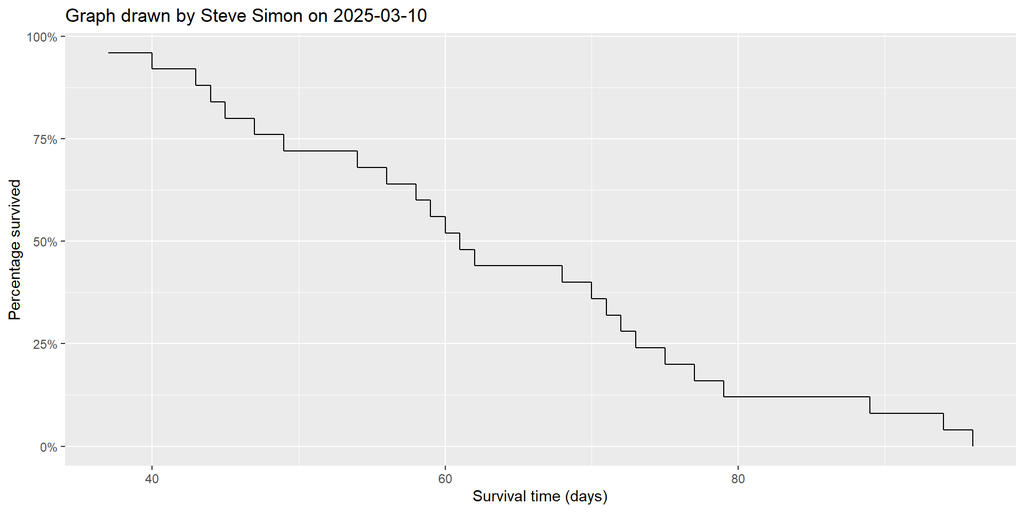

## Second fruit fly experiment, 1

```
37, 40, 43, 44, 45, 47, 49, 54, 56, 58, 59, 60, 61, 62, 68, ??, ??, ??, ??, ??, ??, ??, ??, ??, ??
```

## Second fruit fly experiment, 2

```
  day event
1  37     1
2  40     1
3  43     1
4  44     1
5  45     1
6  47     1
7  49     1
8  54     1
9  56     1
```

```
   day event
10  58     1
11  59     1
12  60     1
13  61     1
14  62     1
15  68     1
16  70     0
17  70     0
18  70     0
```

```
   day event
19  70     0
20  70     0
21  70     0
22  70     0
23  70     0
24  70     0
25  70     0
```

## Second fruit fly experiment, 3

```
  day event   p
1  37     1 96%
2  40     1 92%
3  43     1 88%
4  44     1 84%
5  45     1 80%
6  47     1 76%
7  49     1 72%
8  54     1 68%
9  56     1 64%
```

```
   day event   p
10  58     1 60%
11  59     1 56%
12  60     1 52%
13  61     1 48%
14  62     1 44%
15  68     1 40%
16  70     0
17  70     0
18  70     0
```

```
   day event p
19  70     0
20  70     0
21  70     0
22  70     0
23  70     0
24  70     0
25  70     0
```

## Second fruit fly experiment, 4

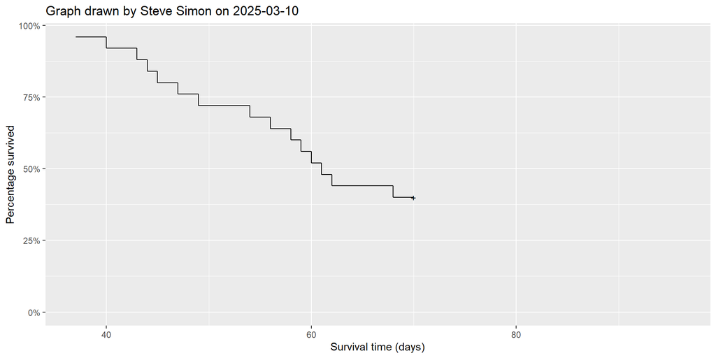

## Third fruit fly experiment, 1

```
37, 40, 43, 44, 45, 47, 49, 54, 56, 58, 59, 60, 61, 62, 68, ??, 71, ??, ??, 75, ??, ??, 89, ??, 96
```

## Third fruit fly experiment, 2

```
  day event
1  37     1
2  40     1
3  43     1
4  44     1
5  45     1
6  47     1
7  49     1
8  54     1
9  56     1
```

```
   day event
10  58     1
11  59     1
12  60     1
13  61     1
14  62     1
15  68     1
16  70     0
17  71     1
18  70     0
```

```
   day event
19  70     0
20  75     1
21  70     0
22  70     0
23  89     1
24  70     0
25  96     1
```

## Third fruit fly experiment, 3

```
  day event   p
1  37     1 96%
2  40     1 92%
3  43     1 88%
4  44     1 84%
5  45     1 80%
6  47     1 76%
7  49     1 72%
8  54     1 68%
9  56     1 64%
```

```
   day event   p
10  58     1 60%
11  59     1 56%
12  60     1 52%
13  61     1 48%
14  62     1 44%
15  68     1 40%
16  70     0
17  71     1 30%
18  70     0
```

```
   day event   p
19  70     0
20  75     1 20%
21  70     0
22  70     0
23  89     1 10%
24  70     0
25  96     1  0%
```

## Third fruit fly experiment, 4

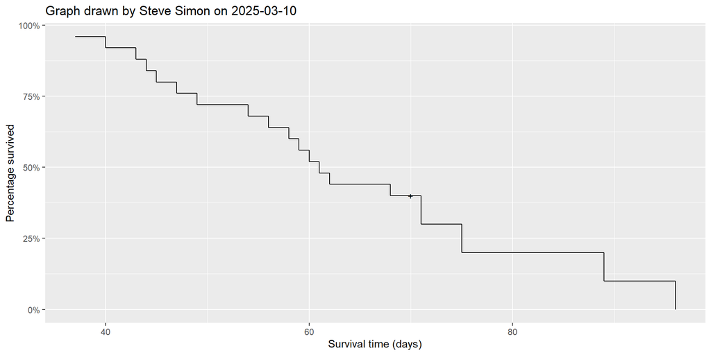

## Interpreting Kaplan-Meier plots, 1

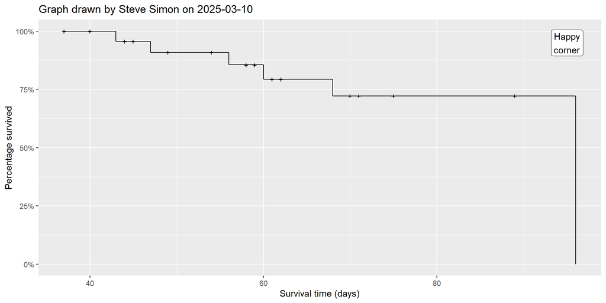

## Interpreting Kaplan-Meier plots, 2

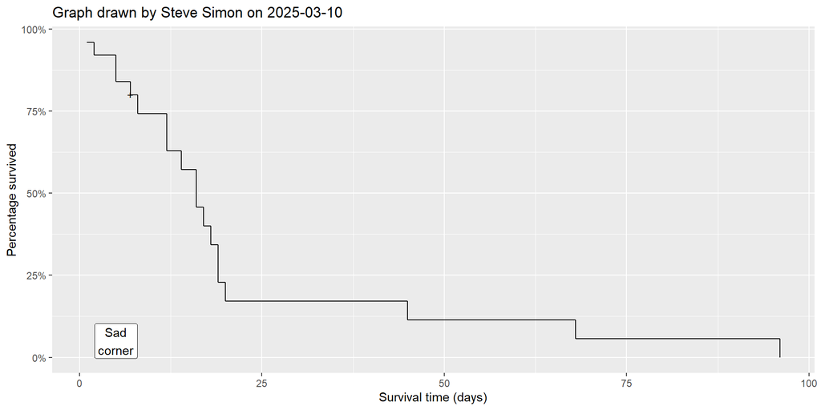

## Interpreting Kaplan-Meier plots, 3

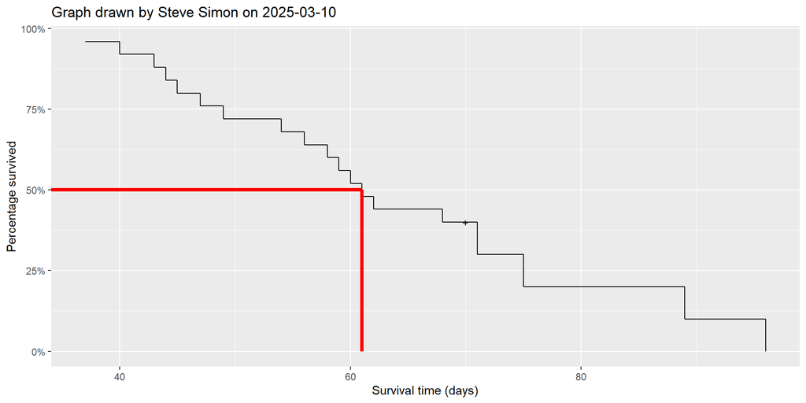

## Interpreting Kaplan-Meier plots, 4

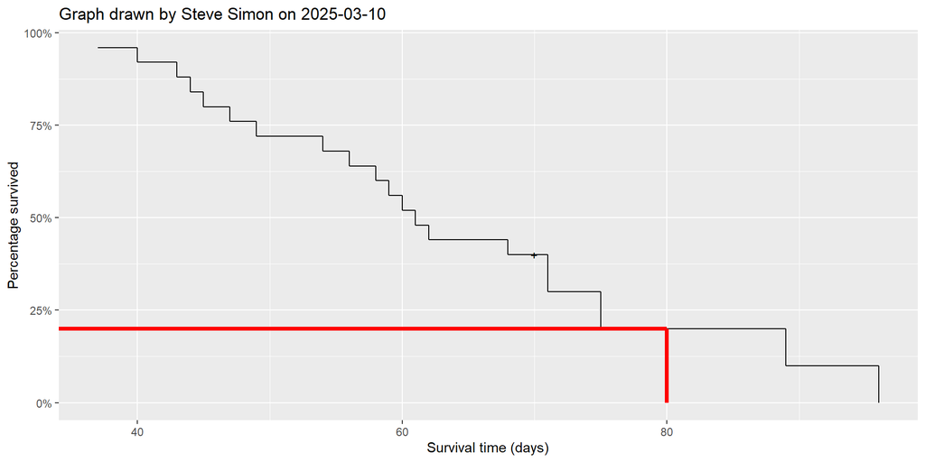

## Break #1

- What you have learned
  - A simple example of survival data
- What’s coming next
  - Kaplan-Meier curve and the log rank test

## Worcester Heart Attack Study, 1

## Event count

```
# A tibble: 2 × 2
  fstat pct
  <dbl> <glue>
1     0 57% (285/500)
2     1 43% (215/500)
```

## Overall Kaplan-Meier curve

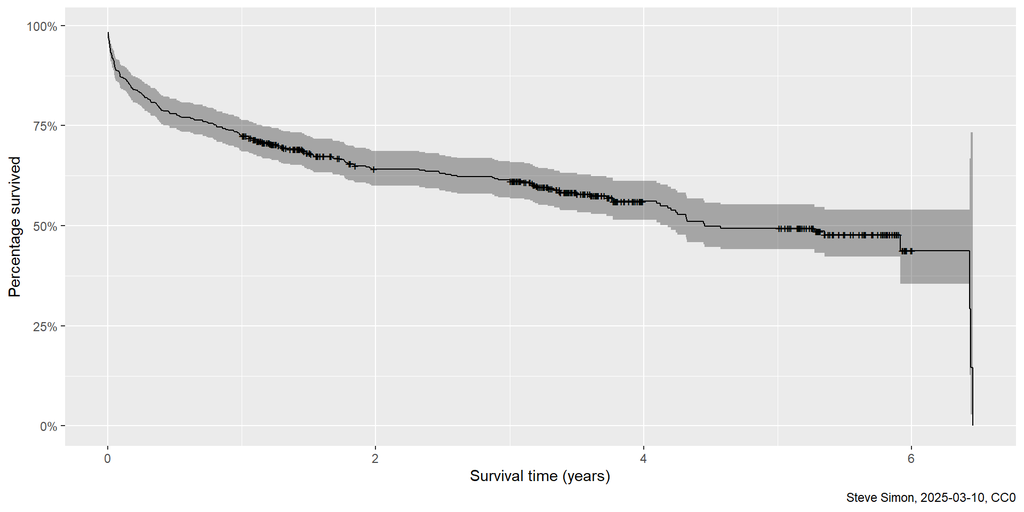

## Kaplan-Meier curve by gender

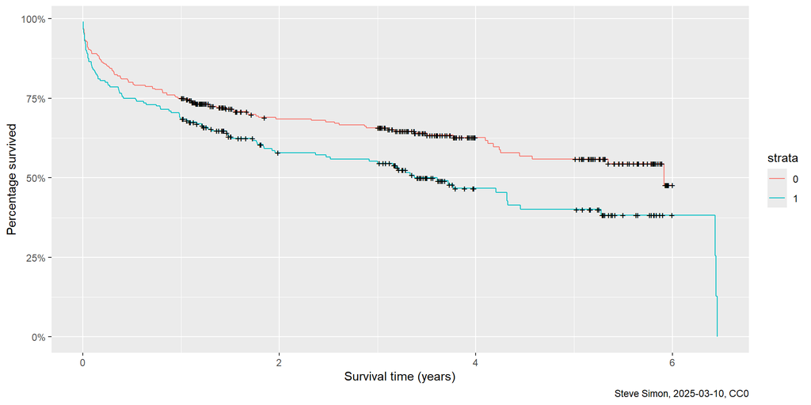

## Log rank test

```
Call:
survdiff(formula = Surv(lenfol, fstat) ~ gender, data = whas1)

           N Observed Expected (O-E)^2/E (O-E)^2/V
gender=0 300      111    130.7      2.98      7.79
gender=1 200      104     84.3      4.62      7.79

 Chisq= 7.8  on 1 degrees of freedom, p= 0.005
```

## Live demo, Kaplan-Meier curve and the log rank test

## Break #2

- What you have learned
  - Kaplan-Meier curve and the log rank test
- What’s coming next
  - The hazard function

## Life insurance example

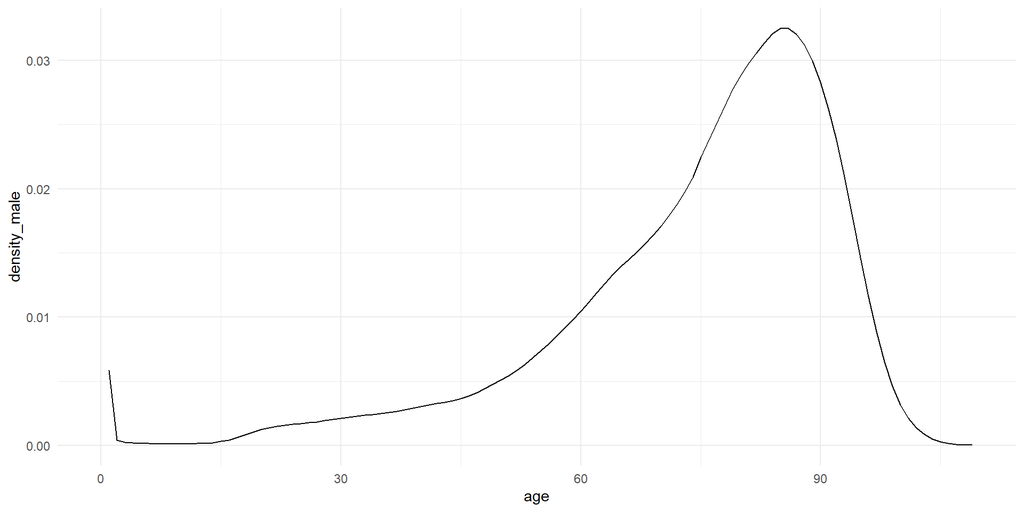

## Probabilities for ages 21 through 41

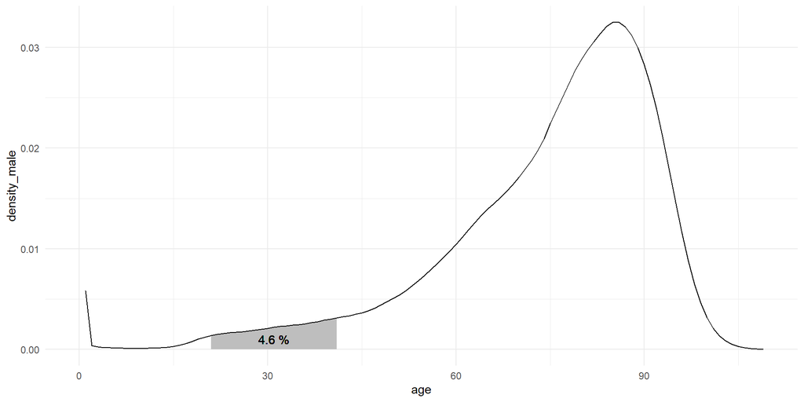

## Probabilities for ages 95 through 99

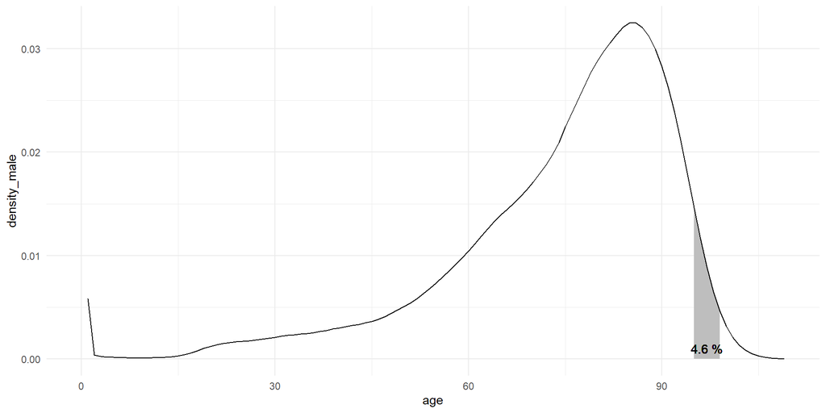

## Why are these probabilities not comparable?

- Unequal time intervals
  - Fix by computing a rate
- Non-uniform probabilities over the interval
  - Fix by looking at narrow interval
- No adjustment for survivorship
  - Fix by dividing by survival probabilty

## Hazard function, definition

- $$h(t)=lim_{\Delta t \rightarrow 0}\frac{P[t \le T \le t+\Delta t]/\Delta t}{P[T \ge t]}$$
- $$h(t)=\frac{f(t)}{S(t)}$$
  - where $f$ is the density function, and
  - $S$ is the survival function ($S(t)=1-F(t)$)

## Hazard function, example

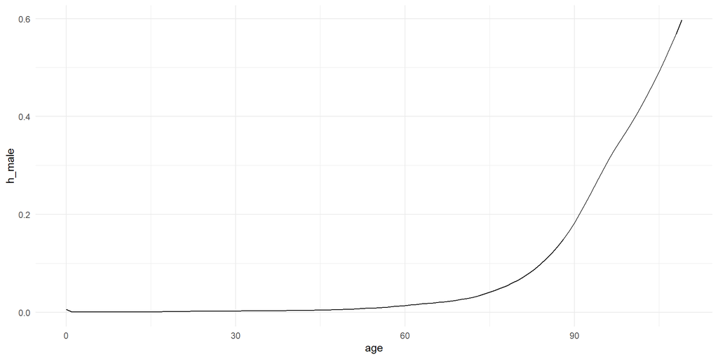

## Hazard function on a log scale

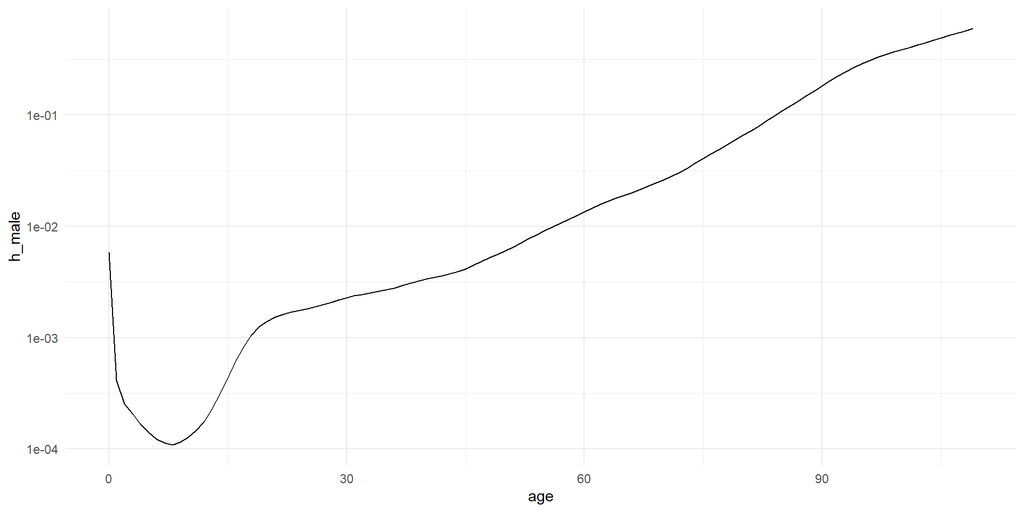

## Live demo, The hazard function

## Break #3

- What you have learned
  - The hazard function
- What’s coming next
  - The Cox regression model

## Cox regression for gender

```
Call:
coxph(formula = Surv(lenfol, fstat) ~ gender, data = whas1)

         coef exp(coef) se(coef)     z       p
gender 0.3815    1.4645   0.1376 2.773 0.00556

Likelihood ratio test=7.6  on 1 df, p=0.005843
n= 500, number of events= 215
```

## Kaplan-Meier plot for age groups

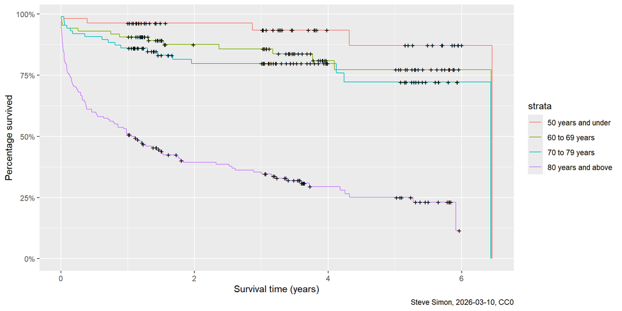

## Cox model for age

```
Call:
coxph(formula = Surv(lenfol, fstat) ~ age_in_decades, data = whas2)

                  coef exp(coef) se(coef)     z      p
age_in_decades 0.66339   1.94136  0.06079 10.91 <2e-16

Likelihood ratio test=142.1  on 1 df, p=< 2.2e-16
n= 500, number of events= 215
```

## Covariate imbalance, 1

```
# A tibble: 2 × 2
  gender age_mean
   <dbl>    <dbl>
1      0     66.6
2      1     74.7
```

## Covariate imbalance, 2

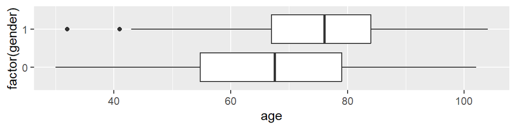

## Cox regression adjusted for age

```
Call:
coxph(formula = Surv(lenfol, fstat) ~ gender + age_in_decades,
    data = whas2)

                   coef exp(coef) se(coef)      z      p
gender         -0.06629   0.93586  0.14058 -0.471  0.637
age_in_decades  0.66928   1.95283  0.06196 10.802 <2e-16

Likelihood ratio test=142.4  on 2 df, p=< 2.2e-16
n= 500, number of events= 215
```

## Break #4

- What you have learned
  - The Cox regression model
- What’s coming next
  - Assumptions and data management

## Assumptions of the log rank test

- Independence
  - From one patient to another
  - Of censoring mechanism

## Assumptions of the Cox regression model

- Independence
- Proportional hazards assumption
- Possible violations of proportional hazards
  - Survival curves that cross
  - One curve flattening out over time
  - Curves diverge only at later times

## Survival curves that cross

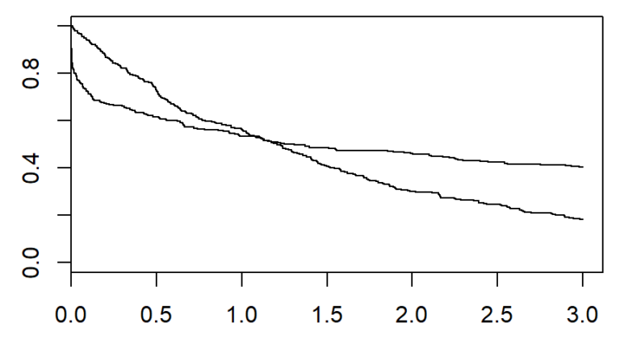

## One curve flattening out over time

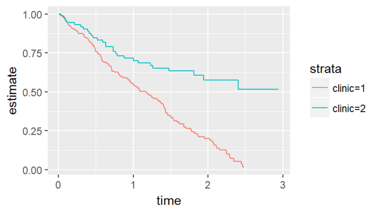

## Curves diverge only at later times

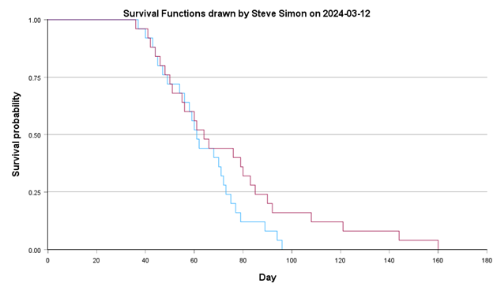

## Sample size issues

- Rule of 50
- Rule of 15

## Use ISO format for dates

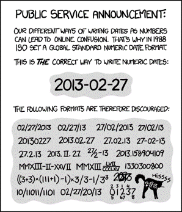

## Understand the internal storage system for dates

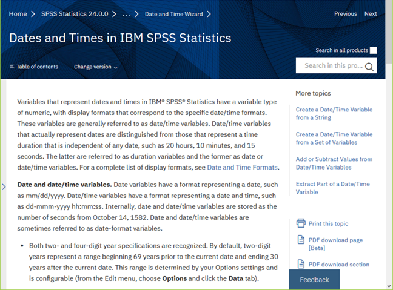

## Date management

- The three dates you need
  - the date of origin,
  - the date of the event (if it occurred),
  - the date of last contact with the patient.

## The date of origin

- Rehospitalization
  - use date of first discharge.
- Failure of a mechanical device
  - use date of implant.
- Divorce
  - use date of marriage.
- Loan default
  - use date of loan contract.
- Infectious disease
  - use date of first exposure.

## The date of the event

- Define your event precisely
  - All-cause mortality
  - Mortality related to the health condition
  - Composite endpoints (e.g., death or relapse)
    - Requires comparing the earlier of two dates.
- If the event did NOT happen, leave this field blank/missing.

## The date of last contact

- If event did not occur
  - Must be specified
  - Typically last medical exam or last telephone contact
- If event did occur
  - Make same as event date, or
  - Leave blank

## Survival calculations, 1 of 2

- Time = max(Date of event, Date of last contact) - Date of origin
- Censoring variable = 0 if Date of event is missing, 1 if not

## Survival calculations, 2 of 2

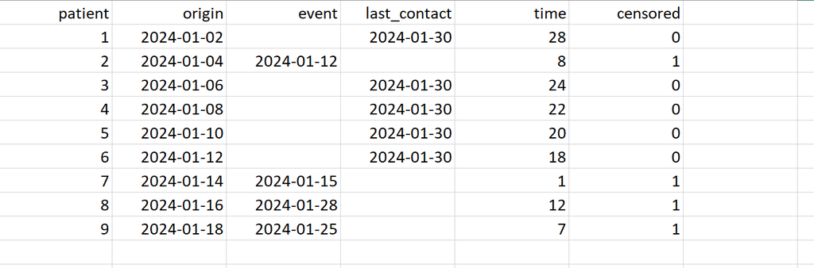

## Summary

- What you have learned
  - A simple example of survival data
  - Kaplan-Meier curve and the log rank test
  - The hazard function
  - The Cox regression model
  - Assumptions and data management